# Travaux_pratique1

Anna ATCHOU

# Contexte

L’objectif de ce projet est que vous appliquiez les outils que vous avez étudiés dans le cours du logiciel statistique R, dans le cas d’une étude de cas réelle. # II- Importation et mise en forme

## II-1 Importation la base de données

```r
library(readxl)
projet<- read_excel("C:/Users/HP/Documents/ISE_1_Eco/R_cours/TPR_1/donnees/Base_Projet.xlsx")
View(projet)
```

## II-2 Nombre de ligne et de colonne

Pour obtenir le nombre de lignes et de colonnes de notre base de données dans R, nous allons utiliser la fonction dim(). la fonction dim() vous donne les dimensions de la base sous la forme d’un vecteur contenant le nombre de lignes et de colonnes.

```r
dimension <- dim(projet) # sors les dimensions de notre base (lignes et colonnes)

print("Nombre de PME :")
```

```
## [1] "Nombre de PME :"
```

```r
print(dimension[1]) # le nombre de ligne
```

```
## [1] 250
```

```r
print(dimension[2]) # le nombre de colonne
```

```
## [1] 33
```

Les resultats de notre code nous montre que notre base contient 250 lignes et 33 colonnes. Dans notre contexte d’étude, 250 PME et 33 variableiables.

## II-3 Vérification de la présence des valeurs manquantes

Ce code vérifie s’il y a des valeurs manquantes pour la variableiable key en utilisant la fonction is.na(). Ensuite, il utilise la fonction which() pour identifier les indices des lignes avec des valeurs manquantes.

```r
# Vérifie s'il y a des valeurs manquantes pour la variable "key"
VM <- is.na(projet$key) # le $ nous permet d'indexer directement notre variable dans la base
VM
```

```
##   [1] FALSE FALSE FALSE FALSE FALSE FALSE FALSE FALSE FALSE FALSE FALSE FALSE
##  [13] FALSE FALSE FALSE FALSE FALSE FALSE FALSE FALSE FALSE FALSE FALSE FALSE
##  [25] FALSE FALSE FALSE FALSE FALSE FALSE FALSE FALSE FALSE FALSE FALSE FALSE
##  [37] FALSE FALSE FALSE FALSE FALSE FALSE FALSE FALSE FALSE FALSE FALSE FALSE
##  [49] FALSE FALSE FALSE FALSE FALSE FALSE FALSE FALSE FALSE FALSE FALSE FALSE
##  [61] FALSE FALSE FALSE FALSE FALSE FALSE FALSE FALSE FALSE FALSE FALSE FALSE
##  [73] FALSE FALSE FALSE FALSE FALSE FALSE FALSE FALSE FALSE FALSE FALSE FALSE
##  [85] FALSE FALSE FALSE FALSE FALSE FALSE FALSE FALSE FALSE FALSE FALSE FALSE
##  [97] FALSE FALSE FALSE FALSE FALSE FALSE FALSE FALSE FALSE FALSE FALSE FALSE
## [109] FALSE FALSE FALSE FALSE FALSE FALSE FALSE FALSE FALSE FALSE FALSE FALSE
## [121] FALSE FALSE FALSE FALSE FALSE FALSE FALSE FALSE FALSE FALSE FALSE FALSE
## [133] FALSE FALSE FALSE FALSE FALSE FALSE FALSE FALSE FALSE FALSE FALSE FALSE
## [145] FALSE FALSE FALSE FALSE FALSE FALSE FALSE FALSE FALSE FALSE FALSE FALSE
## [157] FALSE FALSE FALSE FALSE FALSE FALSE FALSE FALSE FALSE FALSE FALSE FALSE
## [169] FALSE FALSE FALSE FALSE FALSE FALSE FALSE FALSE FALSE FALSE FALSE FALSE
## [181] FALSE FALSE FALSE FALSE FALSE FALSE FALSE FALSE FALSE FALSE FALSE FALSE
## [193] FALSE FALSE FALSE FALSE FALSE FALSE FALSE FALSE FALSE FALSE FALSE FALSE
## [205] FALSE FALSE FALSE FALSE FALSE FALSE FALSE FALSE FALSE FALSE FALSE FALSE
## [217] FALSE FALSE FALSE FALSE FALSE FALSE FALSE FALSE FALSE FALSE FALSE FALSE
## [229] FALSE FALSE FALSE FALSE FALSE FALSE FALSE FALSE FALSE FALSE FALSE FALSE
## [241] FALSE FALSE FALSE FALSE FALSE FALSE FALSE FALSE FALSE FALSE
```

```r
# Identifie les lignes avec des valeurs manquantes pour "key"
WVM <- which(VM=="TRUE")
print("l'entreprise pour laquelle il y a une valeur manquante se trouve à")
```

```
## [1] "l'entreprise pour laquelle il y a une valeur manquante se trouve à"
```

```r
WVM
```

```
## integer(0)
```

D’après les résultats, il n’y a pas de valeurs manquantes pour la variable “Key” dans notre base. En effet, le code avc la fonction is.na() renvoie un booléen ne conteneant que des FALSE, ce qui entraine au niveau de which() integer(0) puisque il ne trouve pas de valeur où c’est TRUE.

# III- Création de variables

## Recodage des variables q1, q2, q23

Pour renommer les variable q1, q2 et q23 nous allons utiliser la fonction rename de la bibliothèque dplyr en R

```r
library(dplyr) # appel de la librairie dplyr
projet <- projet %>% rename(region = q1) # renomme q1 en region
projet <- projet %>% rename(departement = q2) # renomme q2 en departement
projet <- projet %>% rename(sexe = q23) # renomme q23 en sexe
```

## Créqtion de la variable sexe_2 et du dataframe langues

La fonction mutate est utilisée pour créer une nouvelle colonne appelée sexe2 dans le data frame projet. Ensuite on utilise une comparaison booléenne pour vérifier si chaque élément de sexe est égal à “Femme”. L’expression sexe == “Femme” retourne un vecteur de valeurs booléennes (TRUE si l’élément est “Femme”, FALSE sinon), puis la fonction as.numeric() est utilisée pour convertir ces valeurs booléennes en valeurs numériques (1 pour TRUE et 0 pour FALSE).

```r
library(dplyr) # appel de la librairie dplyr
projet <- projet %>% mutate(sexe_2 = as.numeric(sexe == "Femme"))
projet # pour voir la base
```

```
## # A tibble: 250 × 34
##    key         region departement sexe    q24 q24a_1 q24a_2 q24a_3 q24a_4 q24a_5
##    <chr>       <chr>  <chr>       <chr> <dbl>  <dbl>  <dbl>  <dbl>  <dbl>  <dbl>
##  1 uuid:68bff… Diour… Bambey      Femme    65      0      1      0      1      0
##  2 uuid:d70b3… Thiès  Mbour       Femme    52      1      1      0      0      1
##  3 uuid:0ac18… Thiès  Mbour       Femme    65      1      1      0      0      0
##  4 uuid:c52cf… Thiès  Mbour       Femme    38      1      1      0      0      1
##  5 uuid:ac177… Zigui… Bignona     Homme    40      1      1      1      0      0
##  6 uuid:57809… Zigui… Oussouye    Femme    43      1      1      1      0      0
##  7 uuid:c3065… Thiès  Thiès       Femme    53      0      1      0      1      0
##  8 uuid:74e60… Zigui… Ziguinchor  Homme    33      1      0      0      0      0
##  9 uuid:2ee01… Diour… Bambey      Femme    67      0      1      0      1      0
## 10 uuid:5c801… Saint… Dagana      Homme    35      1      1      0      0      0
## # ℹ 240 more rows
## # ℹ 24 more variables: q24a_6 <dbl>, q24a_7 <dbl>, q24a_9 <dbl>, q24a_10 <dbl>,
## #   q25 <chr>, q26 <dbl>, q12 <chr>, q14b <chr>, q16 <chr>, q17 <chr>,
## #   q19 <chr>, q20 <chr>, filiere_1 <dbl>, filiere_2 <dbl>, filiere_3 <dbl>,
## #   filiere_4 <dbl>, q8 <chr>, q81 <chr>, gps_menlatitude <dbl>,
## #   gps_menlongitude <dbl>, submissiondate <dttm>, start <dttm>, today <dttm>,
## #   sexe_2 <dbl>
```

```r
# Création du data.frame langues en utilisant la fonction select
langues <- projet %>%select(key,starts_with("q24a_")) #Nous utilisons la fonction select de dplyr pour sélectionner les variables et starts_with pour sélectionner les variables commençant par q24a_
langues
```

```
## # A tibble: 250 × 10
##    key           q24a_1 q24a_2 q24a_3 q24a_4 q24a_5 q24a_6 q24a_7 q24a_9 q24a_10
##    <chr>          <dbl>  <dbl>  <dbl>  <dbl>  <dbl>  <dbl>  <dbl>  <dbl>   <dbl>
##  1 uuid:68bff42…      0      1      0      1      0      0      0      0       0
##  2 uuid:d70b3c7…      1      1      0      0      1      0      0      0       0
##  3 uuid:0ac18b6…      1      1      0      0      0      0      0      0       0
##  4 uuid:c52cf5e…      1      1      0      0      1      0      0      0       0
##  5 uuid:ac17787…      1      1      1      0      0      1      0      0       0
##  6 uuid:578097c…      1      1      1      0      0      0      0      0       0
##  7 uuid:c3065ed…      0      1      0      1      0      0      0      0       0
##  8 uuid:74e608c…      1      0      0      0      0      0      0      0       1
##  9 uuid:2ee0131…      0      1      0      1      0      0      0      0       0
## 10 uuid:5c801b1…      1      1      0      0      0      0      0      0       1
## # ℹ 240 more rows
```

## Créqtion de la variable parle

Pour cela, nous allons nous interesser à la combinaison des fonctions mutate, across et rowSums mutate est utilisé pour ajouter une nouvelle variable nommée parle. across est utilisé pour sélectionner les colonnes de q24a_1 à q24a_10. rowSums est utilisé pour calculer la somme de chaque ligne.

```r
langues <- langues %>% mutate(parle =rowSums( across(q24a_1:q24a_10)))
langues
```

```
## # A tibble: 250 × 11
##    key     q24a_1 q24a_2 q24a_3 q24a_4 q24a_5 q24a_6 q24a_7 q24a_9 q24a_10 parle
##    <chr>    <dbl>  <dbl>  <dbl>  <dbl>  <dbl>  <dbl>  <dbl>  <dbl>   <dbl> <dbl>
##  1 uuid:6…      0      1      0      1      0      0      0      0       0     2
##  2 uuid:d…      1      1      0      0      1      0      0      0       0     3
##  3 uuid:0…      1      1      0      0      0      0      0      0       0     2
##  4 uuid:c…      1      1      0      0      1      0      0      0       0     3
##  5 uuid:a…      1      1      1      0      0      1      0      0       0     4
##  6 uuid:5…      1      1      1      0      0      0      0      0       0     3
##  7 uuid:c…      0      1      0      1      0      0      0      0       0     2
##  8 uuid:7…      1      0      0      0      0      0      0      0       1     2
##  9 uuid:2…      0      1      0      1      0      0      0      0       0     2
## 10 uuid:5…      1      1      0      0      0      0      0      0       1     3
## # ℹ 240 more rows
```

## Sélection et fusion de base

Nous utilisons select pour sélectionner uniquement les variables key et parle dans le data.frame langues. Ensuite, nous utilisons merge pour fusionner les data.frames projet et langues en utilisant la variable key comme clé de fusion.

```r
langues <- langues%>%select(key, parle) # sélectionne parle et Key dans la base projet et le met dans la base langues
langues
```

```
## # A tibble: 250 × 2
##    key                                       parle
##    <chr>                                     <dbl>
##  1 uuid:68bff42b-1228-4c66-9bcc-e6d312d9fea6     2
##  2 uuid:d70b3c7e-3ca0-4358-bc59-3f7f6baf55e9     3
##  3 uuid:0ac18b64-7d85-4bb9-a842-698ac79909af     2
##  4 uuid:c52cf5e4-8c28-4e65-998b-3fe2a971a1a3     3
##  5 uuid:ac177870-001c-4ada-8747-c22ffe4e4596     4
##  6 uuid:578097cf-9af7-46e6-8992-d9079b14c342     3
##  7 uuid:c3065ed7-c16a-4578-b8fa-e09ffc7bced7     2
##  8 uuid:74e608ca-a37e-47e3-8b22-e1e4bd51fa44     2
##  9 uuid:2ee01315-87e2-4b4a-a19b-107f77bdfc78     2
## 10 uuid:5c801b15-e8fd-4029-af6d-a79efa016520     3
## # ℹ 240 more rows
```

```r
projet <- merge(projet, langues, by = "key") #Fusionner les data.frames projet et langues
projet
```

[output not shown]

[output cut: 1742 more lines]

# Analyses descriptives

## création de la fonction univar pour les statistiques univariées

Il s’agit d’une fonction nommée univar qui prend deux arguments : data et variable. data est l’ensemble de données à partir duquel les statistiques descriptives seront calculées et variable est la variable pour laquelle les statistiques descriptives seront calculées. Ensuite,La fonction freq() est utilisée pour calculer les statistiques descriptives de la variable fournie en argument. En terme de graphique,Si la variable est qualitative, un diagramme en barres est créé à l’aide de barplot() avec le nombre d’occurrences de chaque modalité de la variable en ordonnée. Si la variable est quantitative, un histogramme est créé à l’aide de hist() pour visualiser la distribution des valeurs.

```r
library(janitor)
library(gtsummary)
library(questionr)
```

```r
# Fonction pour les statistiques descriptives univariées
univar <- function(data, variable)
{
stats=freq(variable,cum = TRUE, total = TRUE, sort = "inc", digits = 2, exclude = NA)
cat("STATISTIQUES de ",as.character(substitute(variable)), ":\n")
print(stats)

  # Identifier le type de variable (qualitative ou quantitative)
variable_type <- ifelse(is.factor(variable) || is.character(variable), "Qualitative", "Quantitative")

  # Affichage des statistiques descriptives en fonction du type de variableiable
   if (variable_type == "Qualitative") {

    barplot(table(variable), main = paste("Diagramme en barres de", deparse(substitute(variable))), xlab = deparse(substitute(variable)), ylab = "Fréquence",col=  "sienna3" )

 } else {

    hist(variable, main = paste("Histogramme de", deparse(substitute(variable))),breaks = "Sturges", xlab = deparse(substitute(variable)), ylab = "Fréquence",col= "turquoise3")
 }
attach(data)
}
```

## création de la fonction bivar pour les statistiques bivariées

Ce code est une fonction nommée bivar qui prend trois arguments : data, variable1, et variable2.La fonction commence par vérifier le type des variables données en entrée. Elle utilise les fonctions is.factor() et is.character() pour déterminer si les variables sont qualitatives, et si ce n’est pas le cas, elle les considère comme quantitatives.

**Si les deux variables sont qualitatives, elle crée une table de contingence (xtabs) entre les deux variables et calcule les proportions conditionnelles (cprop). Ensuite, elle génère un diagramme à barres (geom_bar)

**Si les deux variables sont quantitatives, elle crée un nuage de points (geom_point) pour visualiser la relation entre les deux variables

**Si une variable est quantitative et l’autre qualitative, elle crée un boxplot (geom_boxplot) pour visualiser la distribution de la variable quantitative pour chaque niveau de la variable qualitative.

```r
library(ggplot2)
bivar <- function(data, variable1, variable2) {

  # vérification du type de la variable
variable_type1 <- ifelse(is.factor(variable1) || is.character(variable1), "Qualitative", "Quantitative")
variable_type2 <- ifelse(is.factor(variable2) || is.character(variable2), "Qualitative", "Quantitative")

# statistiques selon les types

if (variable_type1 == "Qualitative" & variable_type2 == "Qualitative"){
  tab <- xtabs(~ variable1 + variable2, data)
  stats=cprop(tab)
  print(stats)
  # graphiques
 graph=ggplot(data) +aes(x = variable1, fill = variable2) +geom_bar(position = "dodge") +xlab("")  +ylab("") +labs(title = paste("Diagramme entre", deparse(substitute(variable1)), "et",  deparse(substitute(variable2))), x = deparse(substitute(variable1)), y = "Proportion")
print(graph)
}
if (variable_type1 == "Quantitative" & variable_type2 == "Quantitative"){
 tab <- xtabs(~ variable1 + variable2, data)
  stats=cprop(tab)
  print(stats)
  #Calcul de la corrélation entre les deux variables
 corr <- cor(variable1,variable2)
 cat("Corrélation entre", deparse(substitute(variable1)), "et", deparse(substitute(variable2)), ":", corr, "\n")
 print(corr)
 # graphique
 graph2 <- ggplot(data)+ aes(x = variable1, y = variable2) +geom_point(colour = "turquoise4", alpha = .2)  +labs(title = paste("Nuage de points entre", deparse(substitute(variable1)), "et",   deparse(substitute(variable2))), x = deparse(substitute(variable1)), y = deparse(substitute(variable2)))

print(graph2)


}
if (variable_type1 == "Quantitative" & variable_type2 == "Qualitative" ){
  tab <- xtabs(~ variable1 + variable2, data)
  stats=cprop(tab)
  print(stats)


  # création du boxplot
  graph3 <- ggplot(data, aes(x = variable2,y =variable1)) +
      geom_boxplot() +
      labs(title = paste("Boxplot de", deparse(substitute(variable1)), "par", deparse(substitute(variable2))), x = deparse(substitute(variable2)), y = deparse(substitute(variable1)))

    print(graph3)
}
attach(data)
}
```

Avant de passer à l’analyse descriptive nous allons faire certains recodage. ## recodage des variables q12, q25, q81

```r
projet <- projet %>% rename(statut_juridique = q12)
projet <- projet %>% rename(niveau_instruction = q25)
projet <- projet %>% rename(Propriétaire_locataire = q81)
```

## Répartition de la variable sexe

```r
attach(projet)
univar(projet,sexe)
```

```
## STATISTIQUES de  sexe :
##         n     %  %cum
## Homme  59  23.6  23.6
## Femme 191  76.4 100.0
## Total 250 100.0 100.0
```

[output not shown]

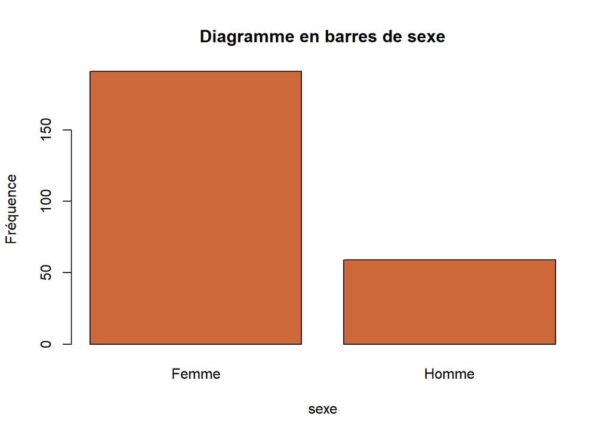

## Répartition de la variable niveau d’instruction

```r
attach(projet)
```

[output not shown]

[output not shown]

```r
univar(projet,niveau_instruction)
```

```
## STATISTIQUES de  niveau_instruction :
##                     n     %  %cum
## Niveau Superieur   41  16.4  16.4
## Niveau primaire    56  22.4  38.8
## Niveau secondaire  74  29.6  68.4
## Aucun niveau       79  31.6 100.0
## Total             250 100.0 100.0
```

[output not shown]

[output not shown]

[output not shown]

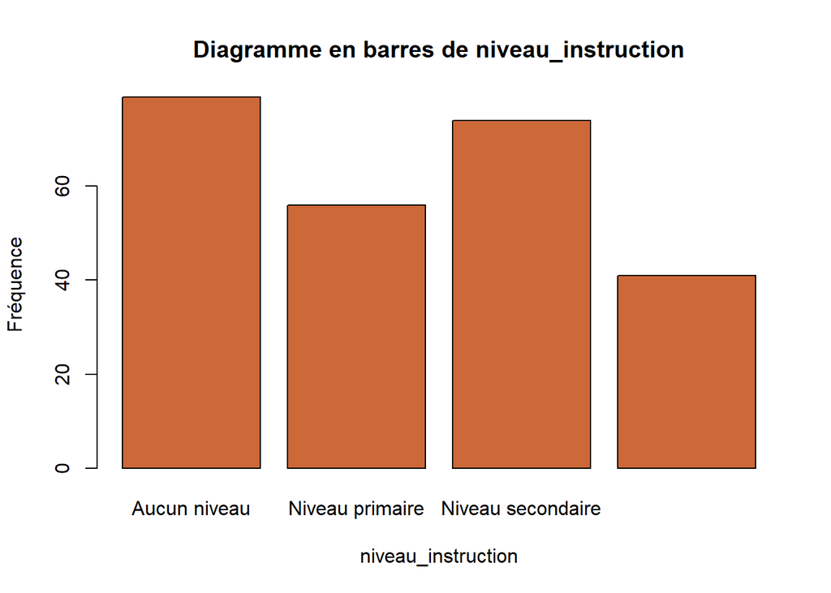

Interprétation

## Répartition de la variable statut_juridique

```r
attach(projet)
```

[output not shown]

[output not shown]

[output not shown]

[output not shown]

```r
univar(projet,statut_juridique)
```

```
## STATISTIQUES de  statut_juridique :
##               n     %  %cum
## Association   6   2.4   2.4
## SA            7   2.8   5.2
## SUARL         7   2.8   8.0
## SARL         13   5.2  13.2
## Informel     38  15.2  28.4
## GIE         179  71.6 100.0
## Total       250 100.0 100.0
```

[output not shown]

[output not shown]

[output not shown]

[output not shown]

[output not shown]

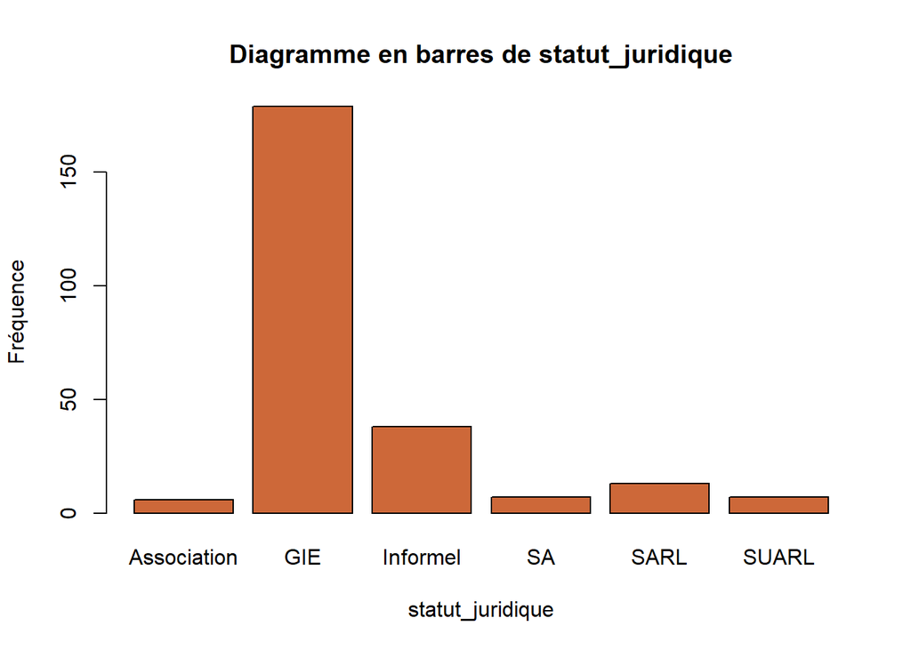

Interprétation

le statut juridique GIE est le plus présent avec une proportion dee 71,6% , suivi des PME Informel (15,2%).Les associations sont les statuts les moins présents. ## Répartition de la variable propriétaire/locataire

```r
attach(projet)
```

[output not shown]

[output not shown]

[output not shown]

[output not shown]

[output not shown]

[output not shown]

```r
univar(projet,Propriétaire_locataire)
```

```
## STATISTIQUES de  Propriétaire_locataire :
##                n     %  %cum
## Locataire     24   9.6   9.6
## Propriétaire 226  90.4 100.0
## Total        250 100.0 100.0
```

[output not shown]

[output not shown]

[output not shown]

[output not shown]

[output not shown]

[output not shown]

[output not shown]

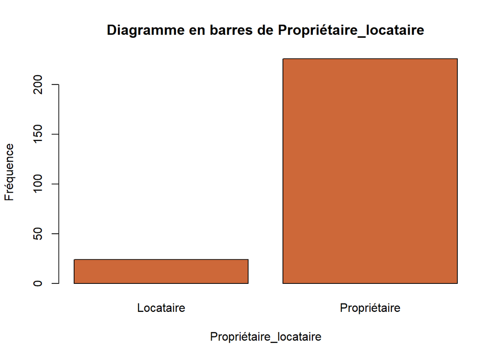

Interprétation

Les propriétaires dominent sur les locataires. 90,4% de propriétaires contre 9,6% de locataires.

## Répartition de la variable statut_juridique et sexe

```r
attach(projet)
```

[output not shown]

[output not shown]

[output not shown]

[output not shown]

[output not shown]

[output not shown]

[output not shown]

[output not shown]

```r
bivar(projet,sexe,statut_juridique)
```

```
##          variable2
## variable1 Association GIE   Informel SA    SARL  SUARL Ensemble
##     Femme  50.0        83.2  84.2     14.3  15.4  57.1  76.4
##     Homme  50.0        16.8  15.8     85.7  84.6  42.9  23.6
##     Total 100.0       100.0 100.0    100.0 100.0 100.0 100.0
```

[output not shown]

[output not shown]

[output not shown]

[output not shown]

[output not shown]

[output not shown]

[output not shown]

[output not shown]

[output not shown]

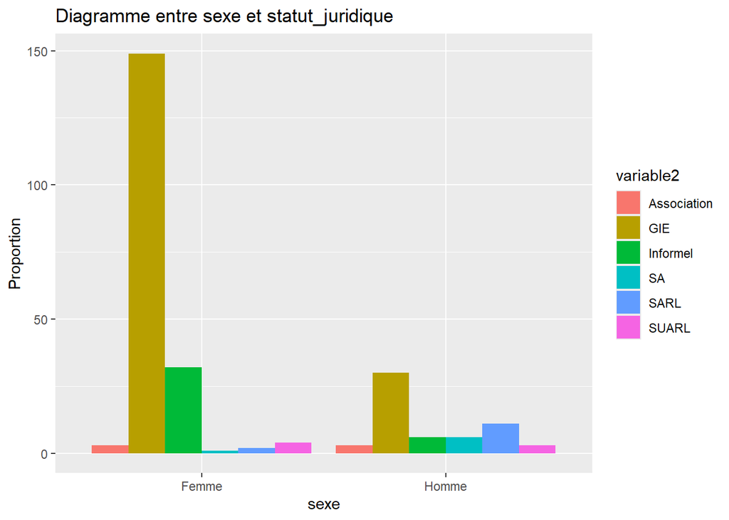

Interprétation

Dans le secteur informel , les femmes dominent avec 84,2% contre 15,8% d’homme.La proportion de PME en association sachant que c’est une femme qui dirige est la même que pour les hommes: 50%.

## Répartition de la variable niveau_instruction et sexe

```r
attach(projet)
```

[output not shown]

[output not shown]

[output not shown]

[output not shown]

[output not shown]

[output not shown]

[output not shown]

[output not shown]

[output not shown]

[output not shown]

```r
bivar(projet,sexe,niveau_instruction)
```

```
##          variable2
## variable1 Aucun niveau Niveau primaire Niveau secondaire Niveau Superieur
##     Femme  88.6         85.7            75.7              41.5
##     Homme  11.4         14.3            24.3              58.5
##     Total 100.0        100.0           100.0             100.0
##          variable2
## variable1 Ensemble
##     Femme  76.4
##     Homme  23.6
##     Total 100.0
```

[output not shown]

[output not shown]

[output not shown]

[output not shown]

[output not shown]

[output not shown]

[output not shown]

[output not shown]

[output not shown]

[output not shown]

[output not shown]

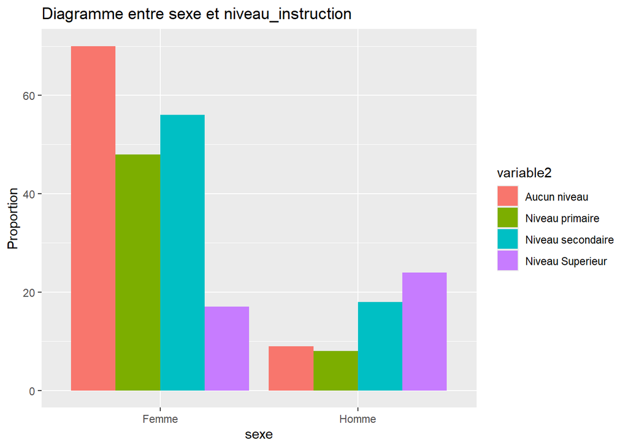

## Répartition de la variable Propriétaire/locataire et sexe

```r
attach(projet)
```

[output not shown]

[output not shown]

[output not shown]

[output not shown]

[output not shown]

[output not shown]

[output not shown]

[output not shown]

[output not shown]

[output not shown]

[output not shown]

[output not shown]

```r
bivar(projet,sexe,Propriétaire_locataire)
```

```
##          variable2
## variable1 Locataire Propriétaire Ensemble
##     Femme  66.7      77.4         76.4
##     Homme  33.3      22.6         23.6
##     Total 100.0     100.0        100.0
```

[output not shown]

[output not shown]

[output not shown]

[output not shown]

[output not shown]

[output not shown]

[output not shown]

[output not shown]

[output not shown]

[output not shown]

[output not shown]

[output not shown]

[output not shown]

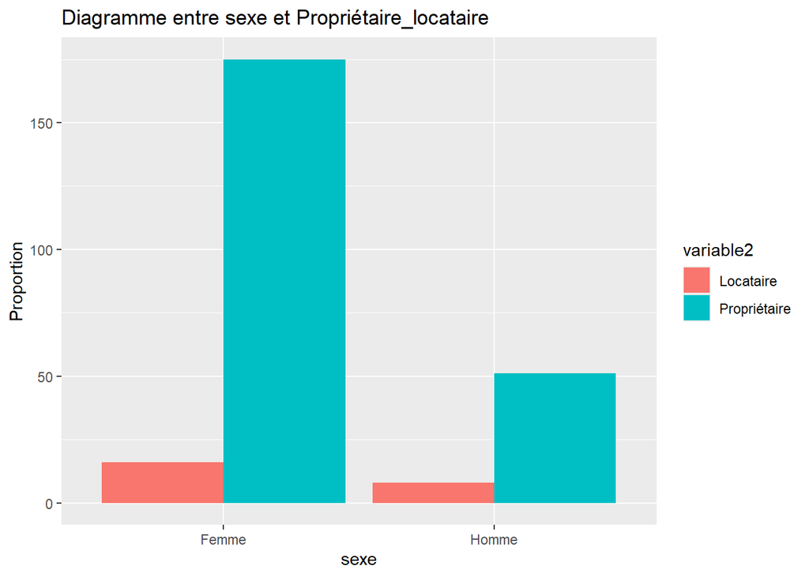

## filière arachide

```r
attach(projet)
```

[output not shown]

[output not shown]

[output not shown]

[output not shown]

[output not shown]

[output not shown]

[output not shown]

[output not shown]

[output not shown]

[output not shown]

[output not shown]

[output not shown]

[output not shown]

[output not shown]

```r
univar(projet,filiere_1)
```

```
## STATISTIQUES de  filiere_1 :
##         n     %  %cum
## 1     108  43.2  43.2
## 0     142  56.8 100.0
## Total 250 100.0 100.0
```

[output not shown]

[output not shown]

[output not shown]

[output not shown]

[output not shown]

[output not shown]

[output not shown]

[output not shown]

[output not shown]

[output not shown]

[output not shown]

[output not shown]

[output not shown]

[output not shown]

[output not shown]

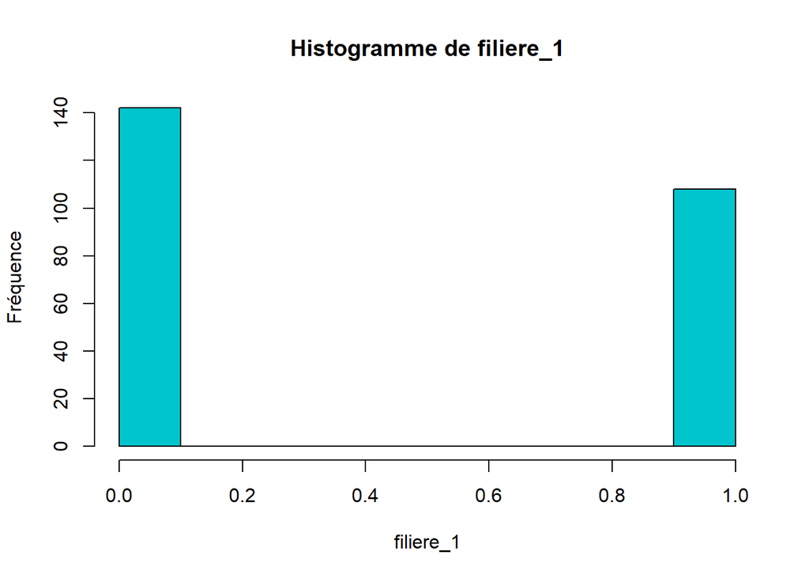

## filière Riz

```r
attach(projet)
```

[output not shown]

[output not shown]

[output not shown]

[output not shown]

[output not shown]

[output not shown]

[output not shown]

[output not shown]

[output not shown]

[output not shown]

[output not shown]

[output not shown]

[output not shown]

[output not shown]

[output not shown]

[output not shown]

```r
univar(projet,filiere_4)
```

```
## STATISTIQUES de  filiere_4 :
##         n     %  %cum
## 1      92  36.8  36.8
## 0     158  63.2 100.0
## Total 250 100.0 100.0
```

[output not shown]

[output not shown]

[output not shown]

[output not shown]

[output not shown]

[output not shown]

[output not shown]

[output not shown]

[output not shown]

[output not shown]

[output not shown]

[output not shown]

[output not shown]

[output not shown]

[output not shown]

[output not shown]

[output not shown]

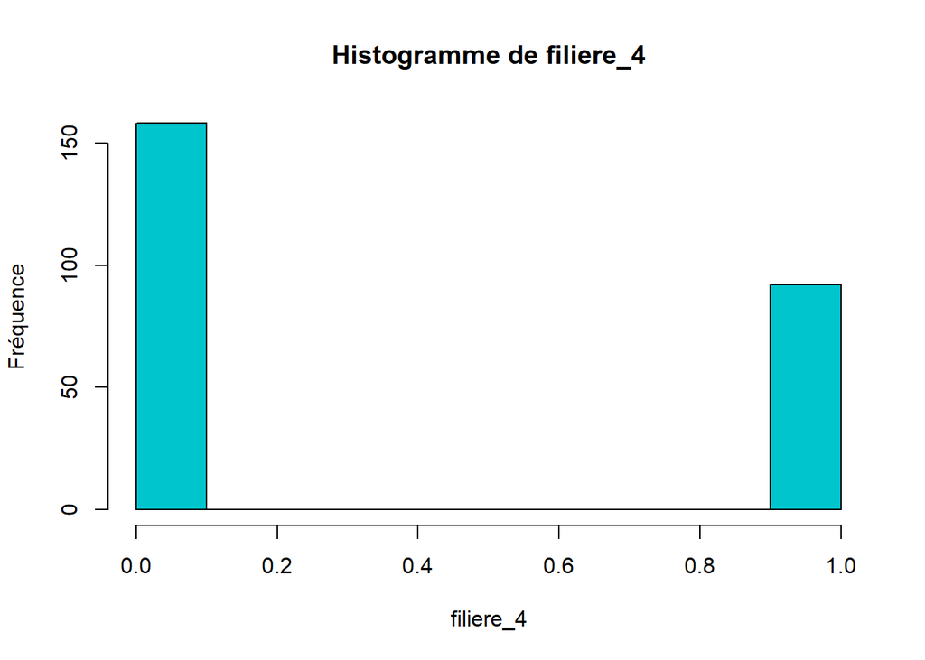

Interprétation Pour la filière riz plus de 60% des PME ne sont pas présents contre une proportion de 36,8% qui y sont.

## Répartion du nombre de femme et d’homme dans la filière riz

```r
attach(projet)
```

[output not shown]

[output not shown]

[output not shown]

[output not shown]

[output not shown]

[output not shown]

[output not shown]

[output not shown]

[output not shown]

[output not shown]

[output not shown]

[output not shown]

[output not shown]

[output not shown]

[output not shown]

[output not shown]

[output not shown]

[output not shown]

```r
bivar(projet,filiere_4,sexe)
```

```
##          variable2
## variable1 Femme Homme Ensemble
##     0      59.7  74.6  63.2
##     1      40.3  25.4  36.8
##     Total 100.0 100.0 100.0
```

[output not shown]

[output not shown]

[output not shown]

[output not shown]

[output not shown]

[output not shown]

[output not shown]

[output not shown]

[output not shown]

[output not shown]

[output not shown]

[output not shown]

[output not shown]

[output not shown]

[output not shown]

[output not shown]

[output not shown]

[output not shown]

[output not shown]

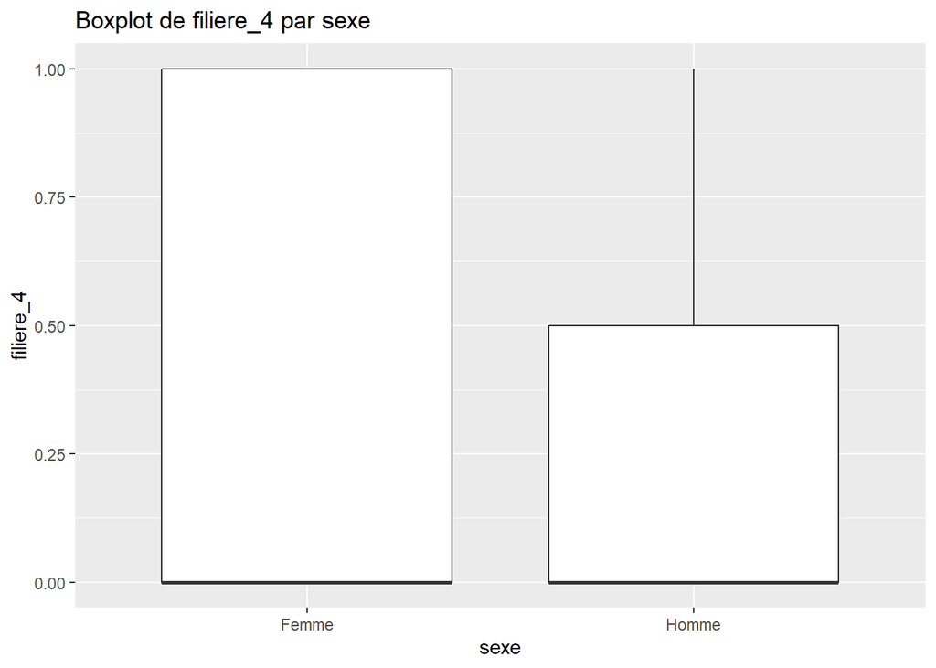

Interprétation

Pour la filière du riz, parmi les PME dont les dirigeants sont des femmes, 40,3% y sont contre 25,4% pour les hommes.